# Modeling and Optimization

## Winter by Calculus

$$\begin{alignat*}{2}
Q^*_2(x_2, u_2) & {}= c\,(u_2 - x_2)^2 + h\,(u_2 - r_2) + c\,(r_3 - u_2)^2 \\[4pt]
\frac{\partial Q^*_2}{\partial u_2} & {}= 2c\,(u_2 - x_2) + h - 2c\,(r_3 - u_2) = 0
\end{alignat*}$$

$$\begin{alignat*}{2}
u^*_2 & {}= \frac{x_2 + r_3}{2} - \frac{h}{4c} \\[4pt]
& {}= \frac{x_2 + 255}{2} - \frac{2000}{4\,(200)} = \frac{x_2 + 250}{2}
\end{alignat*}$$

- One formula for every state ${x_2}$: a **policy**

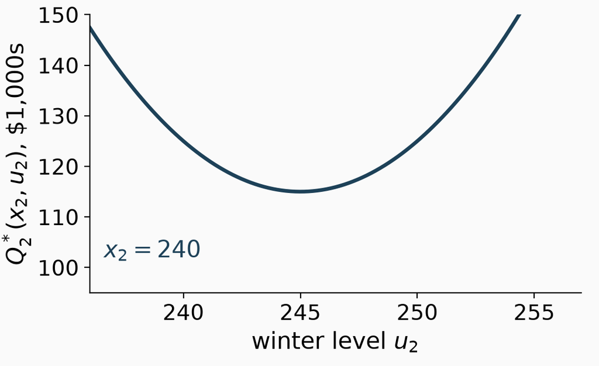

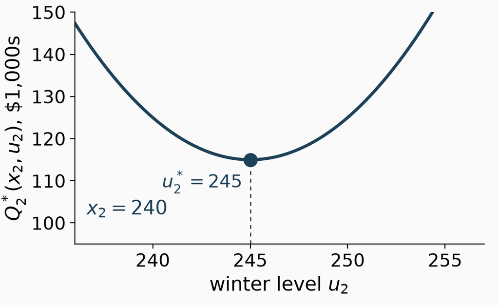

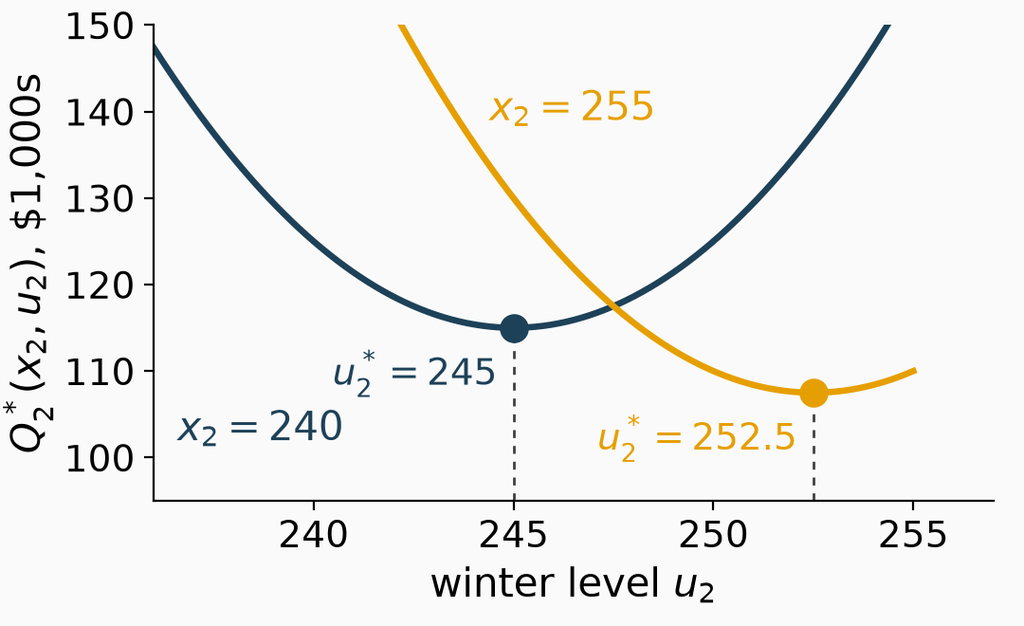

## Winter: The Cost-to-Go as a Formula

- Put ${u^*_2 = (x_2 + r_3)/2 - h/(4c)}$ back into ${Q^*_2}$:

$$\begin{alignat*}{2}
J^*_2(x_2) & {}= Q^*_2\big(x_2, u^*_2\big) \\[4pt]
& {}= \frac{c}{2}\,(r_3 - x_2)^2
+ h\,\Big(\frac{x_2 + r_3}{2} - r_2\Big) - \frac{h^2}{8c} \\[4pt]
& {}= 100\,(255 - x_2)^2
+ 2000\,\Big(\frac{x_2 + 255}{2} - 200\Big) - 2500 \\[4pt]
& {}= 100\,(255 - x_2)^2 + 1000\,x_2 - 147{,}500
\end{alignat*}$$

- Check against the last chart: ${J^*_2(240) = 100\,(15)^2 + 240{,}000 - 147{,}500 = 115{,}000}$

## Autumn by Calculus

- Winter’s formula, at ${x_2 = u_1}$, is autumn’s cost-to-go:

$$\begin{alignat*}{2}
J^*_2(u_1) & {}= \frac{c}{2}\,(r_3 - u_1)^2
+ h\,\Big(\frac{u_1 + r_3}{2} - r_2\Big) - \frac{h^2}{8c} \\[4pt]
Q^*_1(x_1, u_1) & {}= c\,(u_1 - x_1)^2 + h\,(u_1 - r_1) + J^*_2(u_1) \\[4pt]
\frac{\partial Q^*_1}{\partial u_1} & {}= 2c\,(u_1 - x_1) + h - c\,(r_3 - u_1) + \frac{h}{2} = 0
\end{alignat*}$$

$$u_1 = \frac{2x_1 + r_3}{3} - \frac{h}{2c}
= \frac{2x_1 + 255}{3} - \frac{2000}{2\,(200)}
= \frac{2x_1 + 240}{3}$$

- No constraint used so far: is this level at least ${r_1 = 240}$?

## Autumn: The Requirement Binds

- Feasible if ${(2x_1 + 240)/3 \ge 240}$: ${x_1 \ge 240}$
- ${x_1 = 255}$: ${(2\,(255) + 240)/3 = 250}$
- ${x_1 = 228}$: ${(2\,(228) + 240)/3 = 232}$, too low. The cost rises from 240 on, so ${u^*_1 = 240}$

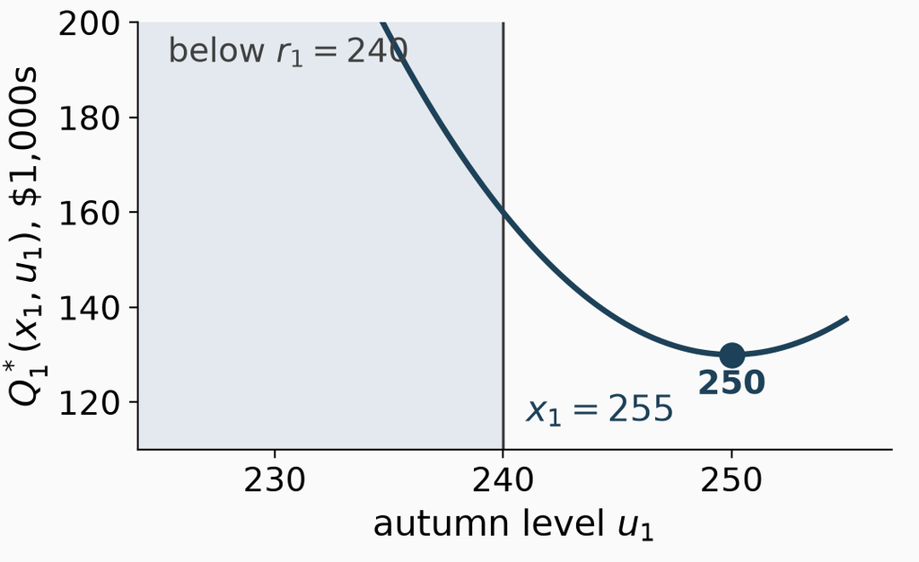

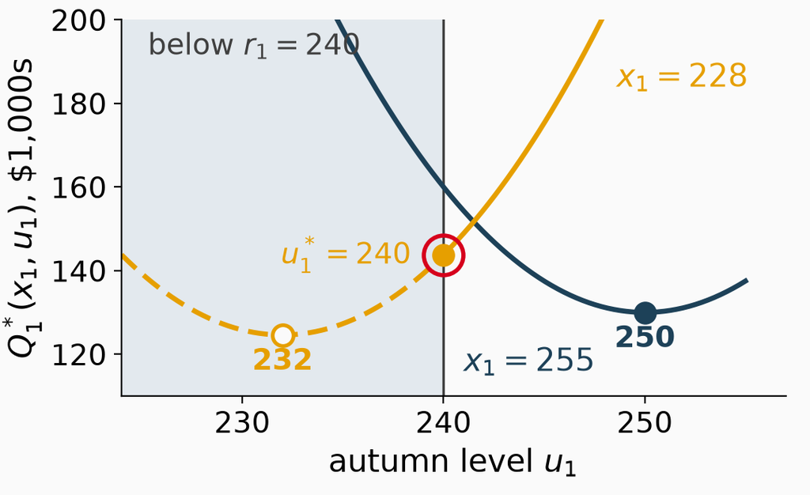

**Autumn’s policy has two pieces: the switch is at 240**

$$u^*_1 = r_1 = 240 \text{ if } x_1 \le 240,
\qquad u^*_1 = \frac{2x_1 + 240}{3} \text{ if } x_1 \ge 240$$

## The Policies Read Forward

- Summer, by the same calculus (appendix): ${u^*_0 = 247.5}$
- ${x_1 = u_0 = 247.5 \ge 240}$, so ${u_1 = (2x_1 + 240)/3 = (2\,(247.5) + 240)/3 = 245}$
- ${x_2 = u_1 = 245}$, so ${u_2 = (x_2 + 250)/2 = (245 + 250)/2 = 247.5}$
- ${x_3 = u_2 = 247.5}$, and ${u_3 = r_3 = 255}$

**Backward for the policies, forward for the plan**

The backward pass gave a rule ${u^*_k(x_k)}$ for every state. The forward pass starts at ${x_0 = 255}$ and applies each rule to the state the last decision produced.

## Summer and the Plan

- Summer: ${\partial Q^*_0/\partial u_0 = 0}$ gives ${u^*_0 = 247.5}$ (appendix). Forward: ${u_1 = 245}$, ${u_2 = 247.5}$, ${u_3 = 255}$

Total cost **$185,000**. gurobipy, as a quadratic program: the same plan

| Season | Level | Change | Surplus |
| --- | --- | --- | --- |
| Summer | 247.5 | 11,250 | 55,000 |
| Autumn | 245 | 1,250 | 10,000 |
| Winter | 247.5 | 1,250 | 95,000 |
| Spring | 255 | 11,250 | 0 |

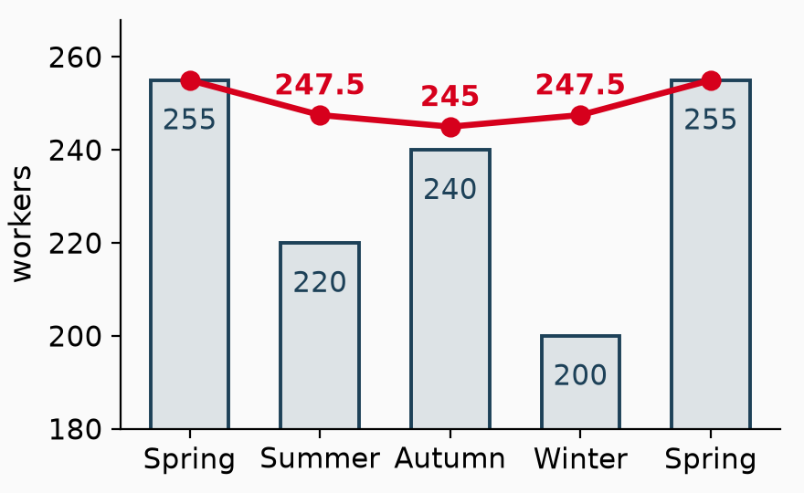

# Probabilistic Recursions: Maximizing a Probability

## When Chance Picks the Next State

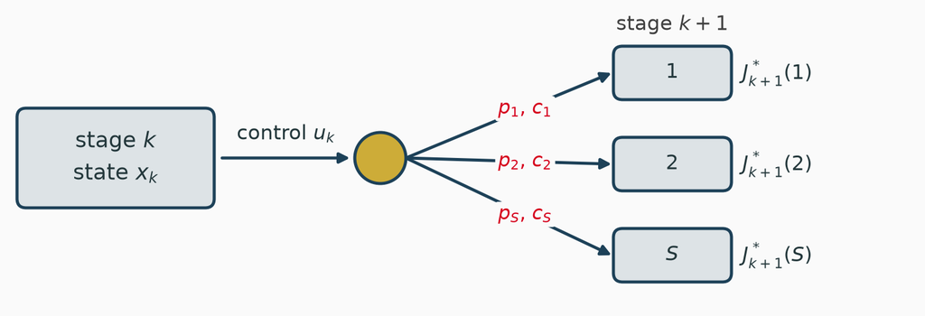

$$\begin{alignat*}{2}
J^*_k(x_k) & {}= \min_{u_k} E_{w_k}\Big[\, g_k(x_k, u_k, w_k) + J^*_{k+1}\big(f_k(x_k, u_k, w_k)\big) \Big] \\[4pt]
& {}= \min_{u_k} \textstyle\sum_{i=1}^{S} p_i \big[\, c_i + J^*_{k+1}(i) \big]
\end{alignat*}$$

${w_k}$: the **disturbance**; ${p_i}$: probability of state ${i}$; ${c_i}$: the cost on that branch.

## Three Chips, Three Plays

- A player’s system wins each play with probability ${2/3}$; a bet of ${x}$ chips wins ${x}$ or loses ${x}$
- The player starts with **3 chips** and wins a side bet with **5 or more** after 3 plays. Maximize the probability of winning it
- Stage ${k}$: play ${k + 1}$; state ${x_k}$: chips in hand; control ${u_k \le x_k}$: chips bet; disturbance ${w_k = +1}$ (win) or ${-1}$: ${x_{k+1} = x_k + w_k u_k}$

$$\begin{alignat*}{2}
Q^*_k(x_k, u_k) & {}= \tfrac{1}{3}\, J^*_{k+1}(x_k - u_k) + \tfrac{2}{3}\, J^*_{k+1}(x_k + u_k) \\[4pt]
J^*_3(x_3) & {}= 1 \text{ if } x_3 \ge 5, \text{ and 0 otherwise}
\end{alignat*}$$

## Plays 3 and 2

| *k* = 2 *x*<sub>2</sub> | ⅓ *J*<sub>3</sub>*(*x*<sub>2</sub> − *u*<sub>2</sub>) + ⅔ *J*<sub>3</sub>*(*x*<sub>2</sub> + *u*<sub>2</sub>) 0 | ⅓ *J*<sub>3</sub>*(*x*<sub>2</sub> − *u*<sub>2</sub>) + ⅔ *J*<sub>3</sub>*(*x*<sub>2</sub> + *u*<sub>2</sub>) 1 | ⅓ *J*<sub>3</sub>*(*x*<sub>2</sub> − *u*<sub>2</sub>) + ⅔ *J*<sub>3</sub>*(*x*<sub>2</sub> + *u*<sub>2</sub>) 2 | ⅓ *J*<sub>3</sub>*(*x*<sub>2</sub> − *u*<sub>2</sub>) + ⅔ *J*<sub>3</sub>*(*x*<sub>2</sub> + *u*<sub>2</sub>) 3 | ⅓ *J*<sub>3</sub>*(*x*<sub>2</sub> − *u*<sub>2</sub>) + ⅔ *J*<sub>3</sub>*(*x*<sub>2</sub> + *u*<sub>2</sub>) 4 | *J*<sub>2</sub>*(*x*<sub>2</sub>) | *u*<sub>2</sub>* |  |  |
| --- | --- | --- | --- | --- | --- | --- | --- | --- | --- |
| 0 | 0 |  |  |  |  |  |  | 0 | any |
| 1 | 0 | 0 |  |  |  | 0 | any |  |  |
| 2 | 0 | 0 | 0 |  |  | 0 | any |  |  |
| 3 | 0 | 0 | ⅓(0) + ⅔(1) = ⅔ | ⅓(0) + ⅔(1) = ⅔ |  | ⅔ | 2 or 3 |  |  |
| 4 | 0 | ⅓(0) + ⅔(1) = ⅔ | ⅓(0) + ⅔(1) = ⅔ | ⅓(0) + ⅔(1) = ⅔ | ⅓(0) + ⅔(1) = ⅔ | ⅔ | 1 to 4 |  |  |
| ≥ 5 |  |  |  |  |  | 1 | 0 to *x*<sub>2</sub> − 5 |  |  |

| *k* = 1 *x*<sub>1</sub> | ⅓ *J*<sub>2</sub>*(*x*<sub>1</sub> − *u*<sub>1</sub>) + ⅔ *J*<sub>2</sub>*(*x*<sub>1</sub> + *u*<sub>1</sub>) 0 | ⅓ *J*<sub>2</sub>*(*x*<sub>1</sub> − *u*<sub>1</sub>) + ⅔ *J*<sub>2</sub>*(*x*<sub>1</sub> + *u*<sub>1</sub>) 1 | ⅓ *J*<sub>2</sub>*(*x*<sub>1</sub> − *u*<sub>1</sub>) + ⅔ *J*<sub>2</sub>*(*x*<sub>1</sub> + *u*<sub>1</sub>) 2 | ⅓ *J*<sub>2</sub>*(*x*<sub>1</sub> − *u*<sub>1</sub>) + ⅔ *J*<sub>2</sub>*(*x*<sub>1</sub> + *u*<sub>1</sub>) 3 | ⅓ *J*<sub>2</sub>*(*x*<sub>1</sub> − *u*<sub>1</sub>) + ⅔ *J*<sub>2</sub>*(*x*<sub>1</sub> + *u*<sub>1</sub>) 4 | *J*<sub>1</sub>*(*x*<sub>1</sub>) | *u*<sub>1</sub>* |  |  |
| --- | --- | --- | --- | --- | --- | --- | --- | --- | --- |
| 0 | 0 |  |  |  |  |  |  | 0 | any |
| 1 | 0 | 0 |  |  |  | 0 | any |  |  |
| 2 | 0 | ⅓(0) + ⅔(⅔) = 4/9 | ⅓(0) + ⅔(⅔) = 4/9 |  |  | 4/9 | 1 or 2 |  |  |
| 3 | ⅓(⅔) + ⅔(⅔) = ⅔ | ⅓(0) + ⅔(⅔) = 4/9 | ⅓(0) + ⅔(1) = ⅔ | ⅓(0) + ⅔(1) = ⅔ |  | ⅔ | 0, 2 or 3 |  |  |
| 4 | ⅓(⅔) + ⅔(⅔) = ⅔ | ⅓(⅔) + ⅔(1) = 8/9 | ⅓(0) + ⅔(1) = ⅔ | ⅓(0) + ⅔(1) = ⅔ | ⅓(0) + ⅔(1) = ⅔ | 8/9 | 1 |  |  |
| ≥ 5 |  |  |  |  |  | 1 | 0 to *x*<sub>1</sub> − 5 |  |  |

## Play 1 and the Policy

| *k* = 0 *x*<sub>0</sub> | ⅓ *J*<sub>1</sub>*(*x*<sub>0</sub> − *u*<sub>0</sub>) + ⅔ *J*<sub>1</sub>*(*x*<sub>0</sub> + *u*<sub>0</sub>) 0 | ⅓ *J*<sub>1</sub>*(*x*<sub>0</sub> − *u*<sub>0</sub>) + ⅔ *J*<sub>1</sub>*(*x*<sub>0</sub> + *u*<sub>0</sub>) 1 | ⅓ *J*<sub>1</sub>*(*x*<sub>0</sub> − *u*<sub>0</sub>) + ⅔ *J*<sub>1</sub>*(*x*<sub>0</sub> + *u*<sub>0</sub>) 2 | ⅓ *J*<sub>1</sub>*(*x*<sub>0</sub> − *u*<sub>0</sub>) + ⅔ *J*<sub>1</sub>*(*x*<sub>0</sub> + *u*<sub>0</sub>) 3 | *J*<sub>0</sub>*(*x*<sub>0</sub>) | *u*<sub>0</sub>* |  |  |
| --- | --- | --- | --- | --- | --- | --- | --- | --- |
| 3 | ⅓(⅔) + ⅔(⅔) = ⅔ | ⅓(4/9) + ⅔(8/9) = 20/27 | ⅓(0) + ⅔(1) = ⅔ | ⅓(0) + ⅔(1) = ⅔ |  |  | 20/27 | 1 |

| Play | Chips | Bet |
| --- | --- | --- |
| 1 | 3 | 1 |
| 2 | 4 (won) | 1 |
| 2 | 2 (lost) | 1 or 2 |
| 3 | 3 or 4 | enough to reach 5 |
| 3 | 5 or more | 0 |

**Probability 20/27 ≈ 0.74**

Bet 1 chip, then adapt: the bet at play 2 depends on what play 1 did. Betting everything at once wins only 2/3.

# Expected-Cost Recursions: A State-Dependent Policy

## Two Engines, Three Auctions

- A repair shop needs **two** refurbished engines within **three weeks**
- One engine is auctioned each week: skip, bid low or bid high. The shop pays only if it wins
- After week 3, each missing engine costs **14** new from the dealer
- **Minimize** the expected total cost

| Bid | Price ($1,000s) | Wins |
| --- | --- | --- |
| Low | 3 | ${1/2}$ |
| High | 6 | ${3/4}$ |

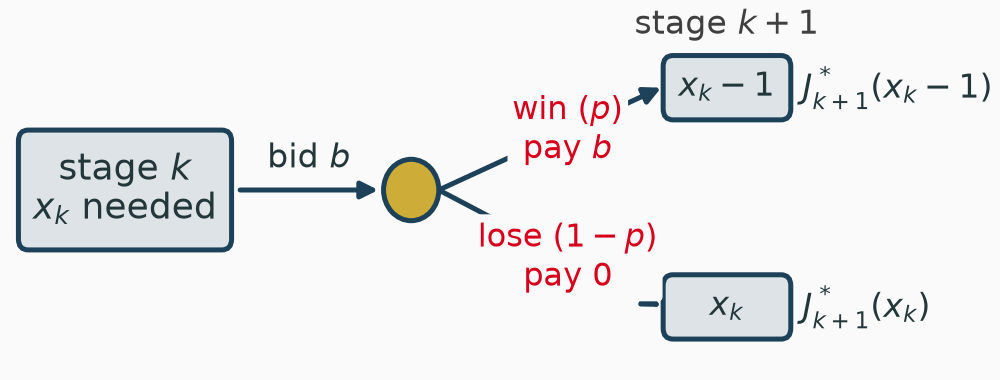

## The Recursion

- Stage ${k}$: week ${k + 1}$; state ${x_k}$: engines still needed (0, 1, 2); control ${u_k}$: skip, low or high
- A bid ${b}$ that wins with probability ${p}$:

$$\begin{alignat*}{2}
Q^*_k(x_k, b) & {}= p\,\big[\, b + J^*_{k+1}(x_k - 1) \,\big] + (1 - p)\, J^*_{k+1}(x_k) \\[4pt]
Q^*_k(x_k, \text{skip}) & {}= J^*_{k+1}(x_k) && \qquad J^*_3(x_3) = 14x_3
\end{alignat*}$$

- Each branch has its **own stage cost**: the bid if won, 0 if lost
- ${J^*_k}$ is an expected cost: the algorithm takes a minimum of averages

## Weeks 3 and 2

| *k* = 2 *x*<sub>2</sub> | *p*(*b* + *J**(*x* − 1)) + (1 − *p*) *J**(*x*); skip: *J**(*x*) Skip | *p*(*b* + *J**(*x* − 1)) + (1 − *p*) *J**(*x*); skip: *J**(*x*) Low | *p*(*b* + *J**(*x* − 1)) + (1 − *p*) *J**(*x*); skip: *J**(*x*) High | *J*<sub>2</sub>*(*x*<sub>2</sub>) | *u*<sub>2</sub>* |  |  |
| --- | --- | --- | --- | --- | --- | --- | --- |
| 0 | 0 |  |  |  |  | 0 | none |
| 1 | 14 | ½(3 + 0) + ½(14) = 8.5 | ¾(6 + 0) + ¼(14) = 8 | 8 | High |  |  |
| 2 | 28 | ½(3 + 14) + ½(28) = 22.5 | ¾(6 + 14) + ¼(28) = 22 | 22 | High |  |  |

| *k* = 1 *x*<sub>1</sub> | *p*(*b* + *J**(*x* − 1)) + (1 − *p*) *J**(*x*); skip: *J**(*x*) Skip | *p*(*b* + *J**(*x* − 1)) + (1 − *p*) *J**(*x*); skip: *J**(*x*) Low | *p*(*b* + *J**(*x* − 1)) + (1 − *p*) *J**(*x*); skip: *J**(*x*) High | *J*<sub>1</sub>*(*x*<sub>1</sub>) | *u*<sub>1</sub>* |  |  |
| --- | --- | --- | --- | --- | --- | --- | --- |
| 0 | 0 |  |  |  |  | 0 | none |
| 1 | 8 | ½(3 + 0) + ½(8) = 5.5 | ¾(6 + 0) + ¼(8) = 6.5 | 5.5 | Low |  |  |
| 2 | 22 | ½(3 + 8) + ½(22) = 16.5 | ¾(6 + 8) + ¼(22) = 16 | 16 | High |  |  |

## Week 1 and the Policy

| *k* = 0 *x*<sub>0</sub> | *p*(*b* + *J**(*x* − 1)) + (1 − *p*) *J**(*x*); skip: *J**(*x*) Skip | *p*(*b* + *J**(*x* − 1)) + (1 − *p*) *J**(*x*); skip: *J**(*x*) Low | *p*(*b* + *J**(*x* − 1)) + (1 − *p*) *J**(*x*); skip: *J**(*x*) High | *J*<sub>0</sub>*(*x*<sub>0</sub>) | *u*<sub>0</sub>* |  |  |
| --- | --- | --- | --- | --- | --- | --- | --- |
| 2 | 16 | ½(3 + 5.5) + ½(16) = 12.25 | ¾(6 + 5.5) + ¼(16) = 12.625 |  |  | 12.25 | Low |

The optimal policy

| Week | One needed | Two needed |
| --- | --- | --- |
| 1 |  | Low |
| 2 | Low | High |
| 3 | High | High |

**Expected cost $12,250**

Bid low while time remains; bid high when the deadline is near and engines are missing. Buying both from the dealer costs $28,000.

# Practice: Allocation and Betting Recursions

## Practice: Four Sales Reps, Three Regions

**Practice Problem**

A firm has four sales reps for three regions. Weekly sales ($1,000s) by the number of reps assigned:

| Reps | 0 | 1 | 2 | 3 | 4 |
| --- | --- | --- | --- | --- | --- |
| Region 1 | 0 | 10 | 17 | 21 | 24 |
| Region 2 | 0 | 6 | 18 | 24 | 27 |
| Region 3 | 0 | 12 | 19 | 23 | 25 |

**(a)** Write the stages, states, controls and DP algorithm.  
**(b)** Solve by backward tables. Is the optimum unique?  
**(c)** Give the reps out one at a time, each where it adds the most. Compare.

## Practice: A Two-Play Bet

**Practice Problem**

A game wins with probability ${1/2}$ and pays **2 to 1**: a bet of ${x}$ chips gains ${2x}$ or loses ${x}$. A player has **3 chips** and two plays, and wants **at least 5 chips** at the end.

**(a)** Write the DP algorithm, with ${J^*_2(x_2)}$ for the end of play 2.  
**(b)** Build the tables for play 2 (chips 0 to 9) and play 1 (3 chips).  
**(c)** Give the optimal policy and the probability of reaching 5.

## Part III: Markov Decision Processes and Reinforcement Learning

When there is no last stage, and when the probabilities must be learned

# Markov Decision Processes and the Bellman Equation

## A Shop with No Last Week

- A shop sells a premium espresso machine. Each Monday it sees its stock ${i}$ (the room holds 3) and orders ${u}$ units; they arrive at once
- Weekly demand is 0, 1 or 2 with probabilities ${1/4}$, ${1/2}$, ${1/4}$; a sale missed is lost

| Sale price | Unit cost | Per order | Per unit left on Sunday |
| --- | --- | --- | --- |
| $800 | $400 | $200 | $100 |

- No week is the last: a dollar next week is worth ${\alpha = 0.8}$ today. Equivalently, each week the product stays on sale with probability 0.8
- **Decide** how much to order in each state, for every week

## Markov Decision Process

**Markov decision process (MDP)**

States ${i}$; controls ${u \in U(i)}$; transition probabilities ${p_{ij}(u)}$; expected stage profit ${g(i, u)}$; discount factor ${0 \le \alpha < 1}$. The next state depends only on the current state and control.

- A stationary policy ${\mu}$ names a control for each state, the same every week
- Its value: ${J_\mu(i) = E\big[\sum_{k \ge 0} \alpha^k\, g(x_k, \mu(x_k)) \mid x_0 = i\big]}$

The shop as an MDP

| State ${i}$ | Control ${u}$ | Profit ${g(i, u)}$ |
| --- | --- | --- |
| Stock on Monday, 0 to 3 | Units ordered, ${u \le 3 - i}$ | Sales minus holding and order cost |

## The Shop’s Data

Everything after the order depends only on the stock ${y = i + u}$:

| Stock *y* | Expected sales | Expected left | *R*(*y*) = 8 sales − left | Next stock 0 | Next stock 1 | Next stock 2 | Next stock 3 |
| --- | --- | --- | --- | --- | --- | --- | --- |
| **0** | 0 | 0 | **0** | 1 |  |  |  |
| **1** | 0.75 | 0.25 | **5.75** | ¾ | ¼ |  |  |
| **2** | 1 | 1 | **7** | ¼ | ½ | ¼ |  |
| **3** | 1 | 2 | **6** |  | ¼ | ½ | ¼ |

- Next stock: probabilities from the demand. Profit: ${g(i, u) = R(i + u) - (2 + 4u)}$ if ${u > 0}$, and ${R(i)}$ if ${u = 0}$

## The Bellman Equation

$$J^*(i) = \max_{u \in U(i)} \Big[\, g(i, u) + \alpha \sum_{j} p_{ij}(u)\, J^*(j) \Big]
\qquad \text{for every } i$$

- Part II’s DP algorithm with the stage index dropped: every week looks the same, so ${J^*_k}$ becomes one function ${J^*}$
- Four equations in four unknowns, with a max: no direct solve

**Two ways to solve it**

**Value iteration:** apply the right-hand side again and again. **Linear programming:** the smallest ${J}$ that satisfies every “${\ge}$” version of the equation.

# Value Iteration and Linear Programming

## Value Iteration

1. Start from ${J_0(i) = 0}$ for every ${i}$
2. Sweep: ${J_{k+1}(i) = \max_u \big[ g(i, u) + \alpha \sum_j p_{ij}(u)\, J_k(j) \big]}$
3. Stop when ${\max_i |J_{k+1}(i) - J_k(i)|}$ is small; act greedily on ${J_{k+1}}$
- ${J_k}$ is the best expected profit over ${k}$ weeks: ${k}$ stages of Part II
- Each sweep cuts the error at least by the factor ${\alpha}$: after ${k}$ sweeps it is at most ${\alpha^k}$ times the first error

**One sweep for the shop, in two steps**

${G_k(y) = R(y) + 0.8 \sum_j P(j \mid y)\, J_k(j)}$, then ${J_{k+1}(i) = \max_{y \ge i} \{ G_k(y) - \text{order cost} \}}$, with order cost ${2 + 4(y - i)}$ if ${y > i}$

## Sweep 1 by Hand

${J_0 = 0}$, so ${G_0(y) = R(y)}$: 0, 5.75, 7, 6.

| sweep 1 *i* | *G*<sub>0</sub>(*y*) − order cost, by stock after ordering *y* 0 | *G*<sub>0</sub>(*y*) − order cost, by stock after ordering *y* 1 | *G*<sub>0</sub>(*y*) − order cost, by stock after ordering *y* 2 | *G*<sub>0</sub>(*y*) − order cost, by stock after ordering *y* 3 | *J*<sub>1</sub>(*i*) | order |  |  |
| --- | --- | --- | --- | --- | --- | --- | --- | --- |
| 0 | 0 | 5.75 − 6 = −0.25 | 7 − 10 = −3 | 6 − 14 = −8 |  |  | 0 | 0 |
| 1 |  | 5.75 | 7 − 6 = 1 | 6 − 10 = −4 | 5.75 | 0 |  |  |
| 2 |  |  | 7 | 6 − 6 = 0 | 7 | 0 |  |  |
| 3 |  |  |  | 6 | 6 | 0 |  |  |

**With one week left, ordering never pays**

A unit bought for $400 plus the $200 fee cannot earn it back in one week: ${5.75 - 6 < 0}$ from an empty shelf.

## Sweep 2 by Hand

| *y* | *R*(*y*) | 0.8 × expected *J*(next) | *G*(*y*) |
| --- | --- | --- | --- |
| **0** | 0 | 0.8(0) = 0 | **0** |
| **1** | 5.75 | 0.2(5.75) + 0.6(0) = 1.15 | **6.9** |
| **2** | 7 | 0.2(7) + 0.4(5.75) + 0.2(0) = 3.7 | **10.7** |
| **3** | 6 | 0.2(6) + 0.4(7) + 0.2(5.75) = 5.15 | **11.15** |

| sweep 2 *i* | *G*<sub>1</sub>(*y*) − order cost, by stock after ordering *y* 0 | *G*<sub>1</sub>(*y*) − order cost, by stock after ordering *y* 1 | *G*<sub>1</sub>(*y*) − order cost, by stock after ordering *y* 2 | *G*<sub>1</sub>(*y*) − order cost, by stock after ordering *y* 3 | *J*<sub>2</sub>(*i*) | order |  |  |
| --- | --- | --- | --- | --- | --- | --- | --- | --- |
| 0 | 0 | 6.9 − 6 = 0.9 | 10.7 − 10 = 0.7 | 11.15 − 14 = −2.85 |  |  | 0.9 | 1 |
| 1 |  | 6.9 | 10.7 − 6 = 4.7 | 11.15 − 10 = 1.15 | 6.9 | 0 |  |  |
| 2 |  |  | 10.7 | 11.15 − 6 = 5.15 | 10.7 | 0 |  |  |
| 3 |  |  |  | 11.15 | 11.15 | 0 |  |  |

## Interactive: Value Iteration

[interactive chart not shown]

## The Optimal Policy

Exact values by solving the Bellman equation for this policy

| Stock ${i}$ | ${J^*(i)}$ ($100s) | Order |
| --- | --- | --- |
| 0 | 6.25 | 2 |
| 1 | 11.875 | 0 |
| 2 | 16.25 | 0 |
| 3 | 18.59 | 0 |

**Order 2 when the shelf is empty**

A **reorder point** of 0 and an order-up-to level of 2: an ${(s, S)}$ policy. The fee makes small, frequent orders expensive.

- The policy settled at sweep 3; the values took 31 sweeps to come within 0.01 of ${J^*}$

## The Bellman Equation as an LP

$$\begin{alignat*}{3}
\min~ & \rlap{\textstyle\sum_i J(i)} \\[4pt]
\text{s.t.}~ & J(i) - \alpha \textstyle\sum_{j} p_{ij}(u)\, J(j) & \quad & {}\ge g(i, u) && \qquad \text{every } i, u
\end{alignat*}$$

- ${J(i)}$ free in sign. One variable per state, one constraint per state and control: 4 and 10 for the shop
- gurobipy: ${J = (6.25, 11.875, 16.25, 18.59)}$; the **tight** constraints are the optimal controls

**Lecture 04 again**

The dual’s variables are discounted state-action frequencies: how often the policy applies control ${u}$ in state ${i}$. Weak and strong duality hold as for any LP.

## The Notebook [dynamic_programming.ipynb](https://colab.research.google.com/drive/1Lrjtdr_hh-BGaIAKJ-FSDbfk7sPc5ksc)

- The stagecoach and the truck by **memoized recursion** in plain Python
- The truck as a gurobipy IP: the same 21
- The Local Job Shop as a gurobipy quadratic program: $185,000
- Value iteration on the shop, and the shop’s MDP as an LP
- Open in Colab, then File, Save a copy in Drive

```python
@lru_cache(maxsize=None)
def J(k, x):
    if k == len(loads):
        return 0
    name, a, v = loads[k]
    return max(J(k + 1, x), v + J(k + 1, x - a)) if a <= x else J(k + 1, x)
```

# Reinforcement Learning: Q-Learning from Samples

## When the Probabilities Are Unknown

- Value iteration needs ${p_{ij}(u)}$. A new product has no demand history
- The Q-factor of a state and control: ${Q^*(i, u) = g(i, u) + \alpha \sum_j p_{ij}(u)\, J^*(j)}$
- Then ${J^*(i) = \max_u Q^*(i, u)}$, and the best control is the ${u}$ that attains it

**Learn Q from experience**

Each week shows one sample: state ${i}$, control ${u}$, profit ${g}$, next state ${j}$. Reinforcement learning estimates ${Q^*}$ from such samples, without writing ${p_{ij}(u)}$ down.

## Q-Learning

After each observed step ${(i, u, g, j)}$:

$$Q(i, u) \leftarrow Q(i, u) + \gamma \Big[\, g + \alpha \max_{v \in U(j)} Q(j, v) - Q(i, u) \,\Big]$$

- The bracket is the error in the Bellman equation, measured on one sample
- ${\gamma}$: the step size, or learning rate; ${\alpha}$ is still the discount
- **Explore:** now and then try an action other than the best so far

**Watkins and Dayan (1992)**

Q-learning converges to ${Q^*}$ if every state-control pair is tried infinitely often and the step sizes shrink suitably.

## Sutton and Barto: Reinforcement Learning

- An **agent** acts in an **environment**, receives rewards and learns a policy by trial and error; the MDP is the model behind it
- Three families: value-based (Q-learning), policy-based (adjust the policy along the gradient of its value), model-based (learn ${p}$, then plan)
- When the states are too many to list, a function approximates ${J}$ or ${Q}$; with a neural network, this is **deep reinforcement learning**

**The bridge**

The Bellman equation of this lecture is the equation those methods solve, from samples, when the transition probabilities are unknown.

## Where Sequential Decisions Appear

Schneider National’s fleet planning used approximate dynamic programming (Simão et al., 2009); backgammon (Tesauro, 1995) and Go (Silver et al., 2016) by reinforcement learning

| Application | State | Decision |
| --- | --- | --- |
| Inventory | Stock on hand | Units to order |
| Revenue management | Seats left, days to departure | Fares to offer |
| Maintenance | Condition of a machine | Repair, replace or wait |
| Truckload fleets | Drivers and loads by city | Which driver takes which load |
| Games | Board position | Next move |

# Practice: Integer and Continuous Recursions

## Practice: An Exam-Style Product Line

**Practice Problem**

| Product | 1 | 2 | 3 |
| --- | --- | --- | --- |
| Start-up cost | 1 | 2 | 0 |
| Marginal net revenue | 5 | 7 | 1 |
| Capacity per unit | 25% | 50% | 25% |

A plant can make three new products. At most 3 units of product 1 sell; products 2 and 3 sell all that is made. Maximize net revenue minus start-up costs.

**(a)** Integer units: dynamic programming with the state in 25% blocks. Give every optimal plan.  
**(b)** Divisible units: dynamic programming with the state in percent.

## Practice: One More Sweep

**Practice Problem**

For the shop, ${J_2 = (0.9, 6.9, 10.7, 11.15)}$ for stock 0 to 3.

**(a)** Compute ${G_2(y)}$ for ${y = 0, \dots, 3}$.  
**(b)** Compute ${J_3(i)}$ and the best order in each state.  
**(c)** Which state’s decision changed from sweep 2?  
**(d)** Check (b) with the stepper.

# Conclusions

## Summary of Part I

**Core takeaways**

- Stages, states, controls; the DP algorithm ${J^*_k(x_k) = \min_{u_k} [g_k + J^*_{k+1}(f_k)]}$
- Solve backward, read forward
- The answer is a policy ${\mu_k(x_k)}$; any ${g_k}$ works

**Watch out for**

- Ties: keep every ${u^*_k}$, they branch the forward pass
- Infeasible decisions: leave the cell blank
- A vector state: the states multiply

## Summary of Part II

**Core takeaways**

- Continuous state: ${J^*_k}$ is a formula; endpoints or calculus
- Probabilistic: ${J^*_k = \min_{u_k} E_{w_k}[g_k + J^*_{k+1}]}$
- The answer is a policy: a decision for each state

**Watch out for**

- Start-up costs break linearity at 0
- Check that a stationary point is feasible
- Each branch has its own stage cost

## Summary of Part III

**Core takeaways**

- No last stage: discount, drop ${k}$, Bellman’s equation
- Value iteration converges; the policy often settles first
- The MDP is also an LP

**Watch out for**

- ${\alpha < 1}$ is what keeps values finite
- Q-learning trades the model for samples and exploration

**Bottom line**

Name the stages and the state first; the recursion follows from them.

## Questions?

Dynamic Programming

MGMT 6460

# Appendix: References and the Job Shop Algebra

## Appendix: Summer by Calculus

For ${x_1 \ge 240}$, the slope of ${J^*_1}$ is that of its first term at ${u^*_1}$:

$$\frac{d J^*_1}{d x_1} = -400\,(u^*_1 - x_1) = -400 \Big( \frac{2x_1 + 240}{3} - x_1 \Big) = \frac{400}{3}(x_1 - 240)$$

With ${x_1 = u_0}$:

$$\frac{\partial Q^*_0}{\partial u_0} = 400(u_0 - 255) + 2000 + \frac{400}{3}(u_0 - 240) = 0$$

Times 3: ${1200u_0 - 306{,}000 + 6{,}000 + 400u_0 - 96{,}000 = 0}$, so ${1600u_0 = 396{,}000}$ and ${u^*_0 = 247.5}$.

- On ${220 \le u_0 \le 240}$ the slope is ${800u_0 - 196{,}000 < 0}$: no minimum there

## Appendix: References

**Textbooks**  
Hillier, F. S. and Lieberman, G. J. *Introduction to Operations Research*, 11th ed. McGraw-Hill, 2021. Source of the stagecoach, the medical teams, the Local Job Shop and Las Vegas.

Bellman, R. *Dynamic Programming*. Princeton University Press, 1957; reprinted 2010. [doi:10.1515/9781400835386](https://doi.org/10.1515/9781400835386)

Bertsekas, D. P. *Dynamic Programming and Optimal Control*, Vol. I, 4th ed. Athena Scientific, 2017.

Denardo, E. V. *Dynamic Programming: Models and Applications*. Dover, 2003.

Puterman, M. L. *Markov Decision Processes: Discrete Stochastic Dynamic Programming*. Wiley, 1994. [doi:10.1002/9780470316887](https://doi.org/10.1002/9780470316887)

## Appendix: Foundations

Bellman, R. The theory of dynamic programming. *Bulletin of the American Mathematical Society* 60(6), 503–515, 1954. [doi:10.1090/S0002-9904-1954-09848-8](https://doi.org/10.1090/S0002-9904-1954-09848-8)

Watkins, C. J. C. H. and Dayan, P. Q-learning. *Machine Learning* 8(3–4), 279–292, 1992. [doi:10.1007/BF00992698](https://doi.org/10.1007/BF00992698)

## Appendix: Structure and Notation

Mitten, L. G. Composition principles for synthesis of optimal multistage processes. *Operations Research* 12(4), 610–619, 1964. [doi:10.1287/opre.12.4.610](https://doi.org/10.1287/opre.12.4.610)

Martin, R. K., Rardin, R. L. and Campbell, B. A. Polyhedral characterization of discrete dynamic programming. *Operations Research* 38(1), 127–138, 1990. [doi:10.1287/opre.38.1.127](https://doi.org/10.1287/opre.38.1.127)

Bertsekas, D. P. *Lecture Slides: Dynamic Programming*, MIT 6.231, Fall 2015. The notation of this lecture. mit.edu/~dimitrib/DP_Slides_2015.pdf

## Appendix: Reinforcement Learning

Powell, W. B. A unified framework for stochastic optimization. *European Journal of Operational Research* 275(3), 795–821, 2019. [doi:10.1016/j.ejor.2018.07.014](https://doi.org/10.1016/j.ejor.2018.07.014)

Sutton, R. S. and Barto, A. G. *Reinforcement Learning: An Introduction*, 2nd ed. MIT Press, 2018.

## Appendix: Applications

Simão, H. P., Day, J., George, A. P., Gifford, T., Nienow, J. and Powell, W. B. An approximate dynamic programming algorithm for large-scale fleet management: a case application. *Transportation Science* 43(2), 178–197, 2009. [doi:10.1287/trsc.1080.0238](https://doi.org/10.1287/trsc.1080.0238)

Tesauro, G. Temporal difference learning and TD-Gammon. *Communications of the ACM* 38(3), 58–68, 1995. [doi:10.1145/203330.203343](https://doi.org/10.1145/203330.203343)

Silver, D., Huang, A., Maddison, C. J., et al. Mastering the game of Go with deep neural networks and tree search. *Nature* 529, 484–489, 2016. [doi:10.1038/nature16961](https://doi.org/10.1038/nature16961)